```r
library(tidyverse)
library(gdata)
library(psych)
library(MCMCpack)
library(readxl)
```

Consideren los datos de tipo de cambio /USD de la sesión 09 (est46114 s06 data.csv).

```r
data <- read_xls("data/est46114_s06_data.xls")
#data <- data.frame(data[,-1], row.names = data[,1])
data <- data %>% dplyr::select(Date,Canada, Mexico, Brazil, EU12,Russia)
date <- as.Date(data$Date)
# Estandarizo
data <- as.data.frame(scale(data[,-1]))
data$Date <- date
```

Entiendo la distribución del tipo de cambio en los países que seleccioné:

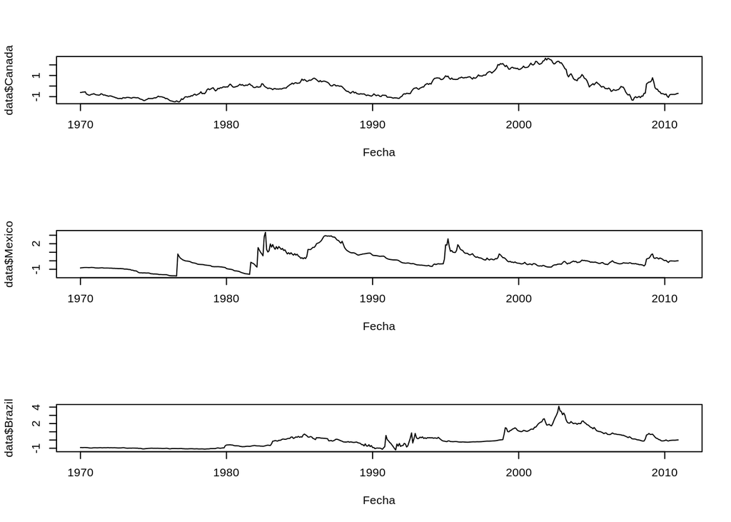

```r
par(mfrow = c(3,1))
plot(data$Date, data$Canada, type = 'l', xlab = 'Fecha')
plot(data$Date, data$Mexico, type = 'l', xlab = 'Fecha')
plot(data$Date, data$Brazil, type = 'l', xlab = 'Fecha')
```

En esta comparativa se observa que Brazil ha seguido patrones mas cercanos a los del movimento del tipo de cambio en Canada. Por el otro lado, aunque México presenta un movimiento similar se observan desfaces respecto a las previas economías.

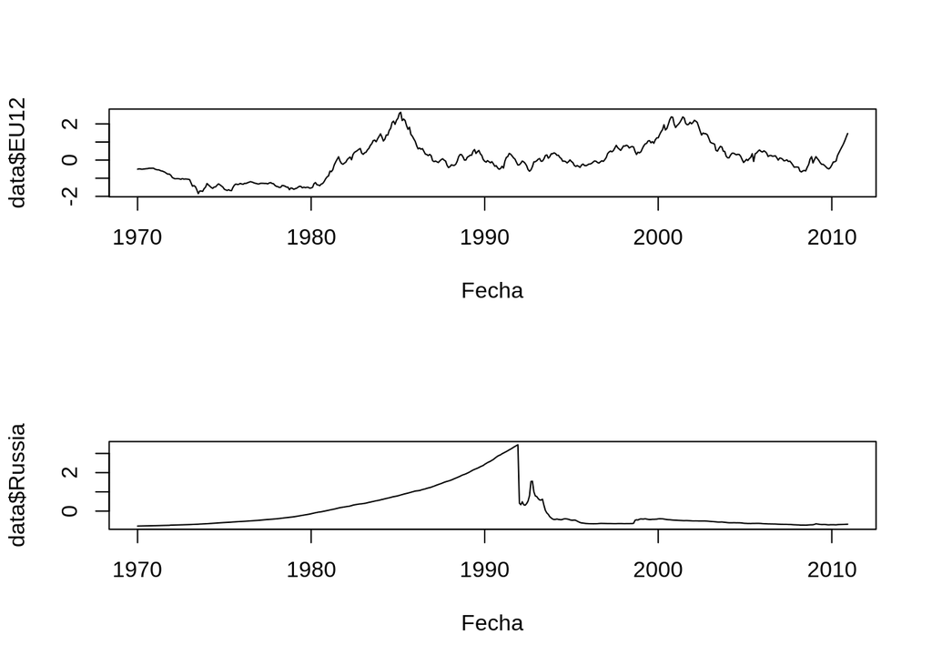

```r
par(mfrow = c(2,1))
plot(as.Date(data$Date), data$EU12, type = 'l', xlab = 'Fecha')
plot(as.Date(data$Date), data$Russia, type = 'l', xlab = 'Fecha')
```

Esta serie de tiempo presenta información con correlación bastante baja, ya que los patrones observados en el grupo EU12 no se manifiestan en la economía de Rusia.

1. Apliquen el analisis de factores dinamicos en estos datos considerando que se recupere un solo factor (eliminando los paises con cambios en nivel significativo).

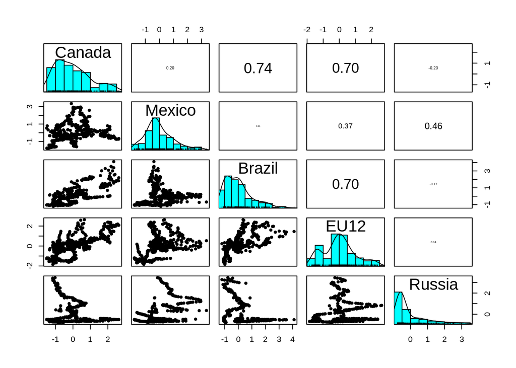

```r
pairs.panels(data[,1:5], ellipses=F, scale=T, smooth=F, col=0)
```

Tras analizar esta gráfica podría ser que las economías de Brasil y Canada hayan tenido la mayor correlación dentro del grupo.

```r
M.sim <- 10000
M.burn <- 500
posterior.data <- MCMCfactanal(~Canada+Mexico+Brazil+EU12+Russia,
                          factors=1,
                          lambda.constraints=list(),
                          verbose=0, store.scores=FALSE,
                          a0=1, b0=0.15,
                          data=data,
                          burnin=M.burn, mcmc=M.sim, thin=20)
```

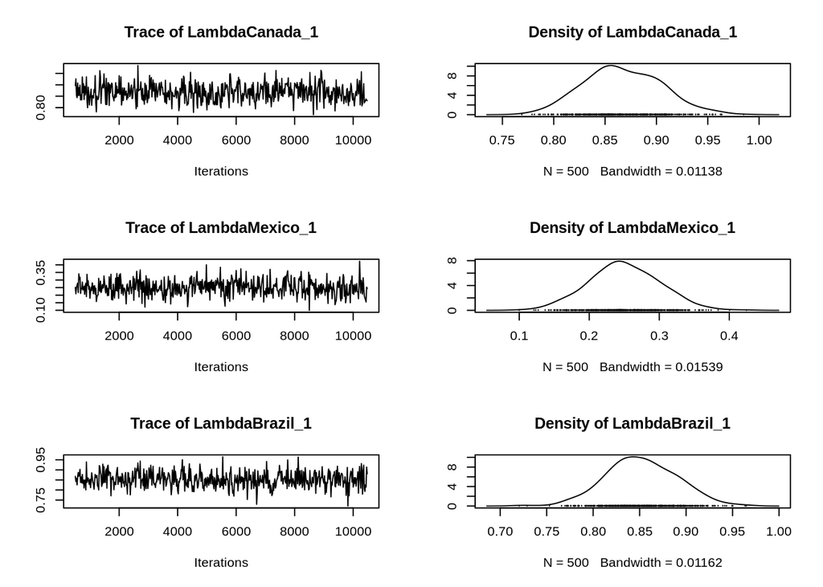

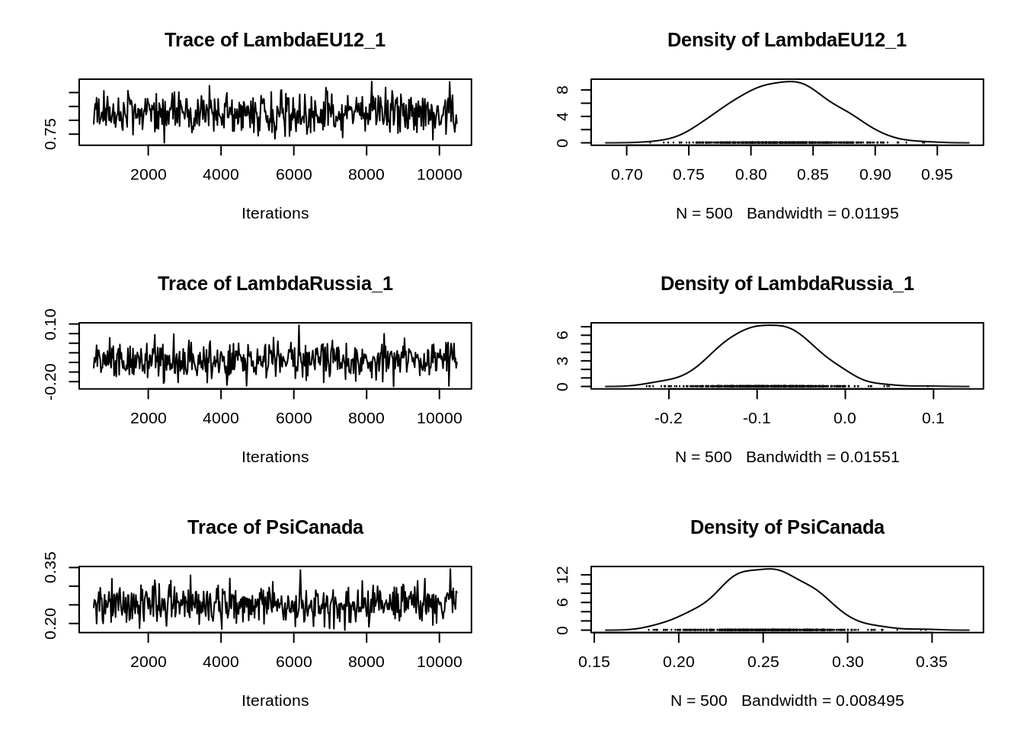

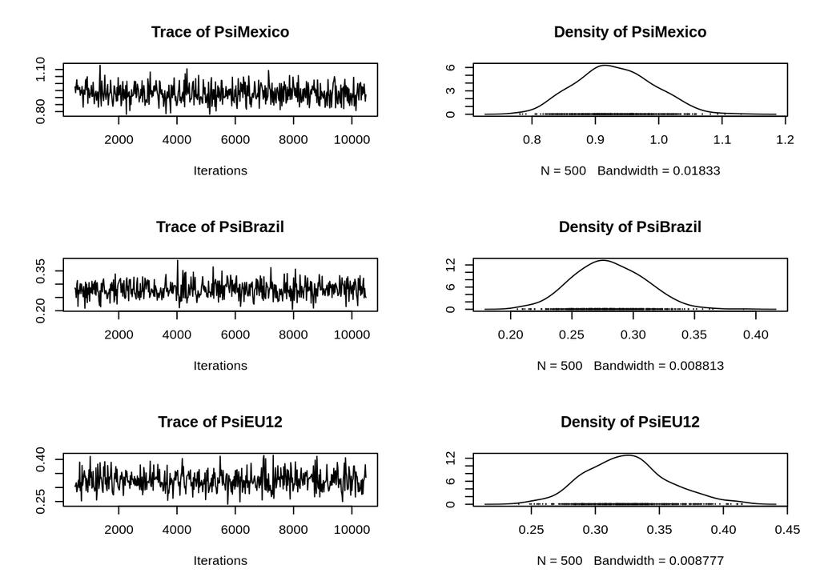

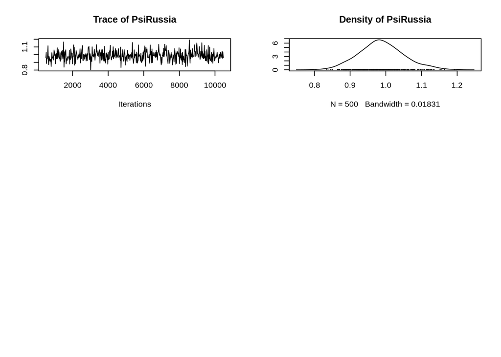

```r
plot(posterior.data)
```

2. Apliquen el analisis de factores dinamicos en estos datos considerando que se recuperen dos factores (eliminando los paises con cambios en nivel significativo).

```r
M.sim <- 10000
M.burn <- 500
posterior.data2 <- MCMCfactanal(~Canada+Mexico+Brazil+EU12+Russia,
                          factors=2,
                          lambda.constraints=list(),
                          verbose=0, store.scores=FALSE,
                          a0=1, b0=0.15,
                          data=data,
                          burnin=M.burn, mcmc=M.sim, thin=20)
```

[figure not shown]

[figure not shown]

[figure not shown]

[figure not shown]

```r
plot(posterior.data2)
```

3. Comparen las distribuciones y niveles medios del primer factor del inciso anterior con el factor unico del primer inciso. Discutan que pasa con los niveles medios y la dispersion subyacente de estos dos factores.

Primer factor

```r
dist_1factCan <-  as.data.frame(posterior.data[,1])
dist_1factCan$Type <- rep('1° Factor', length(dist_1factCan))

dist_1factMex <- as.data.frame(posterior.data[,2])
dist_1factMex$Type <- rep('1° Factor', length(dist_1factMex))

dist_1factBra <- as.data.frame(posterior.data[,3])
dist_1factBra$Type <- rep('1° Factor', length(dist_1factBra))

dist_1factEU12 <- as.data.frame(posterior.data[,4])
dist_1factEU12$Type <- rep('1° Factor', length(dist_1factEU12))

dist_1factRus <- as.data.frame(posterior.data[,5])
dist_1factRus$Type <- rep('1° Factor', length(dist_1factRus))

dist_2factCan <- as.data.frame(posterior.data2[,1])
dist_2factCan$Type <- rep('2° Factor', length(dist_2factCan))

dist_2factMex <- as.data.frame(posterior.data2[,3])
dist_2factMex$Type <- rep('2° Factor', length(dist_2factMex))

dist_2factBra <- as.data.frame(posterior.data2[,5])
dist_2factBra$Type <- rep('2° Factor', length(dist_2factBra))

dist_2factEU12 <- as.data.frame(posterior.data2[,7])
dist_2factEU12$Type <- rep('2° Factor', length(dist_2factEU12))

dist_2factRus <- as.data.frame(posterior.data2[,9])
dist_2factRus$Type <- rep('2° Factor', length(dist_2factRus))

Canada <- rbind(dist_1factCan, dist_2factCan)
Mexico <- rbind(dist_1factMex, dist_2factMex)
Brazil <- rbind(dist_1factBra, dist_2factBra)
EU12 <- rbind(dist_1factEU12, dist_2factEU12)
Russia <- rbind(dist_1factRus, dist_2factRus)
```

Comparación Canadá

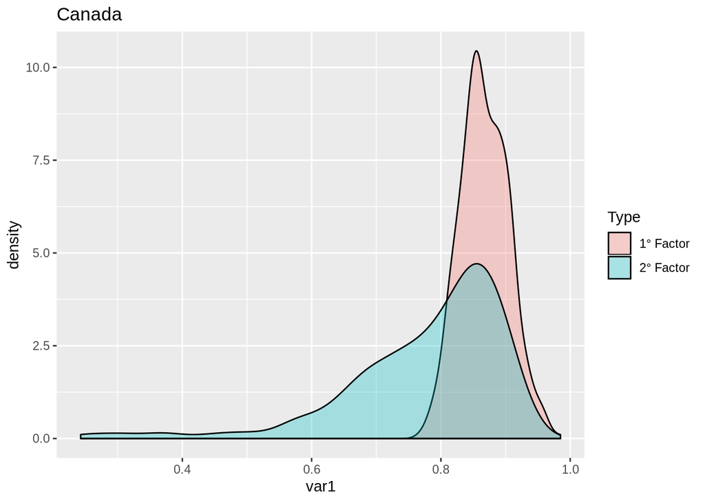

```r
ggplot(Canada, aes(x=var1, fill=Type)) + geom_density(alpha=.3) + ggtitle('Canada')
```

Comparación México

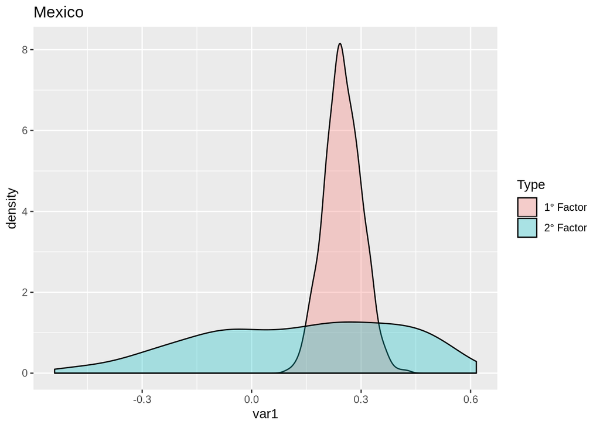

```r
ggplot(Mexico, aes(x=var1, fill=Type)) + geom_density(alpha=.3) + ggtitle('Mexico')
```

Comparación Brasil

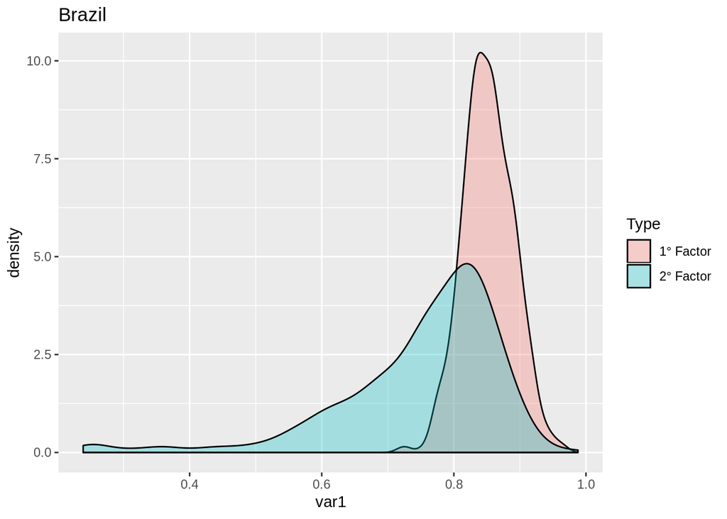

```r
ggplot(Brazil, aes(x=var1, fill=Type)) + geom_density(alpha=.3) + ggtitle('Brazil')
```

Comparación EU12

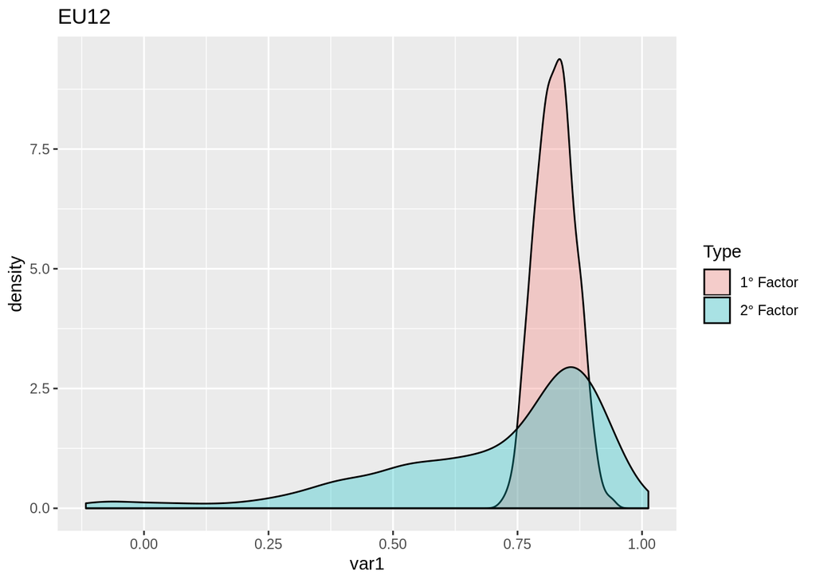

```r
ggplot(EU12, aes(x=var1, fill=Type)) + geom_density(alpha=.3) + ggtitle('EU12')
```

Comparación Russia

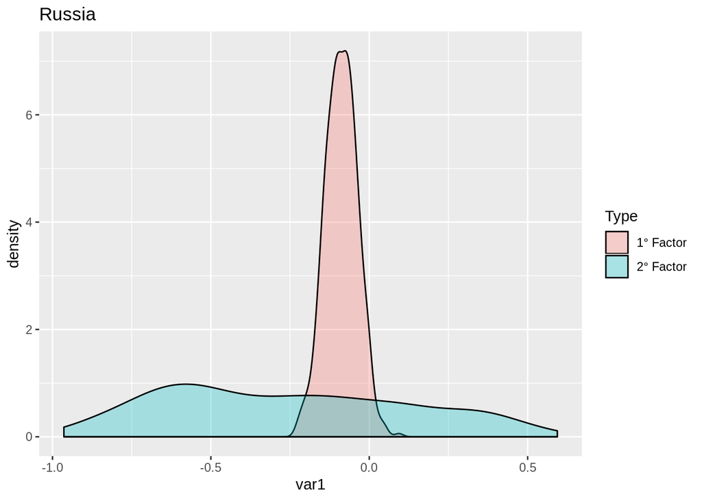

```r
ggplot(Russia, aes(x=var1, fill=Type)) + geom_density(alpha=.3) + ggtitle('Russia')
```